# Homework 7

CS 498, Spring 2018, Xiaoming Ji

# Problem 1

**EM Topic models** The UCI Machine Learning dataset repository hosts several datasets recording word counts for documents here. You will use the NIPS dataset. You will find (a) a table of word counts per document and (b) a vocabulary list for this dataset at the link. You must implement the multinomial mixture of topics model.

```r
#Load data
header = readLines("docword.nips.txt", n = 2)
DocCount = as.integer(header[1])
VocabSize = as.integer(header[2])
df = read.table("docword.nips.txt", skip=3)

DocVectors = matrix(0, DocCount, VocabSize)
for (i in 1:(dim(df)[1])){
  DocVectors[df[i, 1],df[i, 2]] = df[i, 3]
}
```

- Cluster this to 30 topics, using a simple mixture of multinomial topic model.

We have,
$$\omega_{i,j}=\frac{\left[\prod_{k} p_{j,k}^{x_{i,k}}\right]\pi_j}{ \sum_{l} \left[\prod_{k} p_{l,k}^{x_{i,k}}\right]\pi_l}$$
We transform this equation to logsumexp form to benefit calculation
$$\log(\omega_{i,j})=\sum_{k}(x_{i,k}\log p_{j,k}) + \log\pi_j - LogSumExp_l(\sum_{k}(x_{i,k}\log p_{l,k}) + \log\pi_{l})$$

```r
library(matrixStats)

topic_EM = function(docs, vocab.size, topic.count, threshold = 1e-7){
  #Initialize P and Pi
  doc_count = dim(docs)[1]
  doc_length = rowSums(docs)
  P  = matrix(0, topic.count, vocab.size)
  pi = rep(0, topic.count)
  W = matrix(0, doc_count, topic.count)
  old_W  = W
  log_W = W

  #Randomly sample docs
  i_doc = sample(1:doc_count, doc_count)

  bat_size = round(doc_count / topic.count)
  s = 1
  e = bat_size

  for (j in 1:topic.count) {
    if (e > doc_count) e = doc_count

    i_bat = i_doc[s:e]

    #count words and add smoothing
    words = colSums(docs[i_bat,])

    #Calculate P and Pi
    P[j,]  = words / sum(words)
    pi[j] = length(i_bat) / doc_count

    s = e + 1
    e = e + bat_size
  }

  #Iterately perform E and M steps
  for (iter in 1:1000) {
    #smooth P
    P = P + 1e-7
    P = P / rowSums(P)

    log_P = log(P)
    log_pi = log(pi)

    #Calculate Q (for testing only)
    # X_log_P = docs %*% t(log(P))
    # Q = 0
    # for (i in 1:doc_count) {
    #   for (j in 1:topic.count){
    #     Q = Q + (X_log_P[i,j] + log_pi[j]) * W[i,j]
    #   }
    # }
    # print(paste("Q=",Q, sep=""))

    #E Step
    X_log_P = docs %*% t(log_P)
    for (i in 1:doc_count) {
      log_W[i, ] = X_log_P[i, ] + log_pi
      log_W[i, ] = log_W[i, ] - logSumExp(log_W[i, ])
    }

    W = exp(log_W)
    t_W = t(W)

    d = max(abs(W - old_W))
    print(paste("Iteration=", iter, ", D=", d, sep=""))
    if(d < threshold) break()

    old_W = W

    #M Step
    P = (t_W %*% docs) / c(t_W %*% doc_length)
    pi = colSums(W) / doc_count
  }

  return (list(W=old_W, P=P, pi=pi))
}
```

```r
TopicCount = 30

r=topic_EM(DocVectors, VocabSize, TopicCount)
```

```
## [1] "Iteration=1, D=1"
## [1] "Iteration=2, D=0.0483597190735626"
## [1] "Iteration=3, D=0.00270059583425319"
## [1] "Iteration=4, D=0.00024090993147835"
## [1] "Iteration=5, D=2.73801227291814e-05"
## [1] "Iteration=6, D=3.08834389722845e-06"
## [1] "Iteration=7, D=3.47327533456454e-07"
## [1] "Iteration=8, D=3.90169124231399e-08"
```

- Produce a graph showing, for each topic, the probability with which the topic is selected.

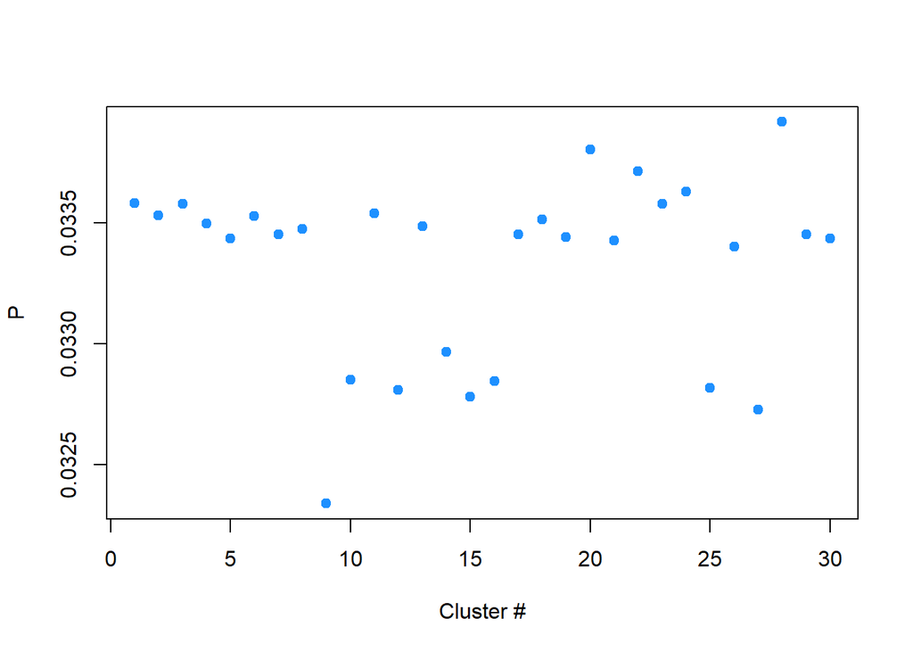

```r
plot(r$pi, xlab = "Cluster #", ylab = "P",
     col = "dodgerblue", pch = 20, cex = 1.5)
```

- Produce a table showing, for each topic, the 10 words with the highest probability for that topic.

```r
top_10 = matrix(0, TopicCount, 10)
P = r$P

for (i in 1:TopicCount) {
  for (j in 1: 10) {
    top_10[i, j] = which.max(P[i,])
    P[i, top_10[i, j]] = 0
  }
}

print(top_10)
```

```
##       [,1] [,2]  [,3]  [,4]  [,5]  [,6]  [,7]  [,8]  [,9] [,10]
##  [1,] 7358 7011  5399 10003  4270  7365 11020 11418  2574 11719
##  [2,] 7358 6120  4270   316  7011 11020  5399  7365 11418  8628
##  [3,] 7358 5399  7011 10003  6120  4270 11719 11020  2574  7874
##  [4,] 7358 7011  6120 10003  4270 11020  5399 11418  7365  2574
##  [5,] 7358 7011  5399   316  7365  7874 11719  4270 10003 12153
##  [6,] 7358 7011  7365  4270  2574 11020  6120 10003  5399 11418
##  [7,] 7358 6120  7011  5399 11719  4270   316 11901 11020 10003
##  [8,] 7358 6120  4270  7011  5399 12153 10003  2574 11719 11418
##  [9,] 7358 7011  4270  6120  5399 10003  7365  2574 11020 12153
## [10,] 6120 7011  7358  4270   316 10003  7365 11020 11418  8628
## [11,] 7011 7358  6120  4270  7365  5399  2574 11020  7391  3603
## [12,] 7358 6120  4270  7011 11719  5399 12153   316 10003  2574
## [13,] 7358 7011  6120 10003   316  2574 11020 11901  5399  4270
## [14,] 7358 7011 11020  6120  5399  4270 10003   316  7365  2574
```

[output cut: 16 more lines]

# Problem 2

**Image segmentation using EM** You can segment an image using a clustering method - each segment is the cluster center to which a pixel belongs. In this exercise, you will represent an image pixel by its r, g, and b values (so use color images!). Use the EM algorithm applied to the mixture of normal distribution model lectured in class to cluster image pixels, then segment the image by mapping each pixel to the cluster center with the highest value of the posterior probability for that pixel. You must implement the EM algorithm yourself (rather than using a package). Test images are here, and you should display results for all three of them. Till then, use any color image you care to.

- Segment each of the test images to 10, 20, and 50 segments. You should display these segmented images as images, where each pixel’s color is replaced with the mean color of the closest segment
- We will identify one special test image. You should segment this to 20 segments using five different start points, and display the result for each case. Is there much variation in the result?